# Team 1 Final Project Code

Team 1 (Names: Adam Kritz, Osemekhian Ehilen, Suhas Buravalla, Huang He)

2021-12-05

# Midterm Code

## Importing the Data

```r
diamonds = data.frame(read.csv("diamonds.csv"))
diamonds$color = factor(diamonds$color, order=T, levels = c('J', 'I', 'H', 'G', 'F', 'E', 'D'))
diamonds$clarity = factor(diamonds$clarity, order=T, levels = c('I1', 'SI2', 'SI1', 'VS2', 'VS1', 'VVS2', 'VVS1', 'IF'))
diamonds$cut = factor(diamonds$cut, order=T, levels = c('Fair', 'Good', 'Very Good', 'Premium', 'Ideal'))
colnames(diamonds)[1] = "ID"
```

## EDA Code

### summary table

```r
sum = xkablesummary(diamonds, title = "Summary of Diamonds")
sum
```

Summary of Diamonds

|  | ID | carat | cut | color | clarity | depth | table | price | x | y | z |
| --- | --- | --- | --- | --- | --- | --- | --- | --- | --- | --- | --- |
| Min | Min. : 1 | Min. :0.20 | Fair : 1610 | J: 2808 | SI1 :13065 | Min. :43.0 | Min. :43.0 | Min. : 326 | Min. : 0.00 | Min. : 0.0 | Min. : 0.0 |
| Q1 | 1st Qu.:13486 | 1st Qu.:0.40 | Good : 4906 | I: 5422 | VS2 :12258 | 1st Qu.:61.0 | 1st Qu.:56.0 | 1st Qu.: 950 | 1st Qu.: 4.71 | 1st Qu.: 4.7 | 1st Qu.: 2.9 |
| Median | Median :26970 | Median :0.70 | Very Good:12082 | H: 8304 | SI2 : 9194 | Median :61.8 | Median :57.0 | Median : 2401 | Median : 5.70 | Median : 5.7 | Median : 3.5 |
| Mean | Mean :26970 | Mean :0.80 | Premium :13791 | G:11292 | VS1 : 8171 | Mean :61.7 | Mean :57.5 | Mean : 3933 | Mean : 5.73 | Mean : 5.7 | Mean : 3.5 |
| Q3 | 3rd Qu.:40455 | 3rd Qu.:1.04 | Ideal :21551 | F: 9542 | VVS2 : 5066 | 3rd Qu.:62.5 | 3rd Qu.:59.0 | 3rd Qu.: 5324 | 3rd Qu.: 6.54 | 3rd Qu.: 6.5 | 3rd Qu.: 4.0 |
| Max | Max. :53940 | Max. :5.01 | NA | E: 9797 | VVS1 : 3655 | Max. :79.0 | Max. :95.0 | Max. :18823 | Max. :10.74 | Max. :58.9 | Max. :31.8 |
| NA | NA | NA | NA | D: 6775 | (Other): 2531 | NA | NA | NA | NA | NA | NA |

### Categorical Data Exploration

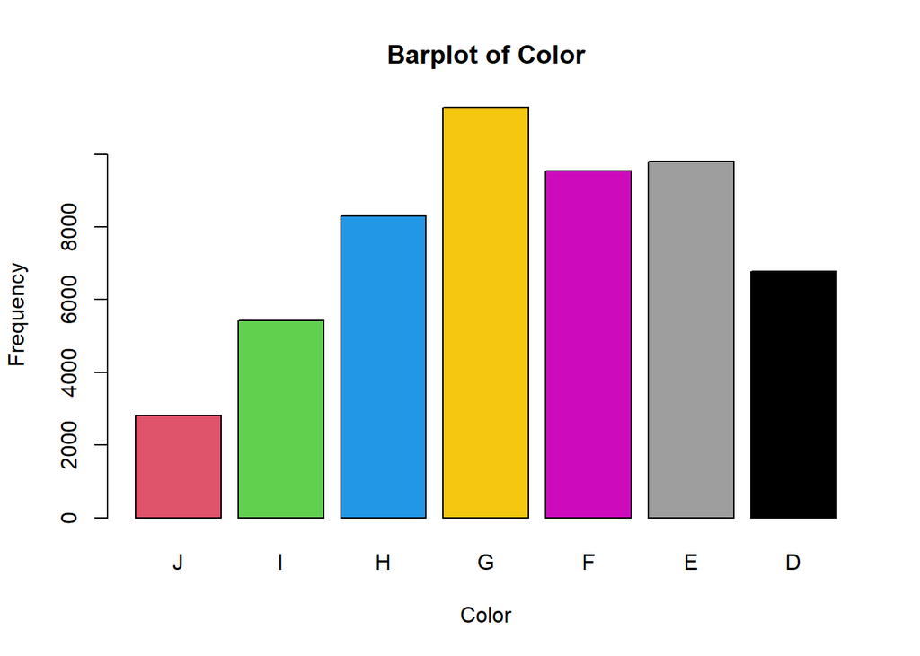

```r
barplot(table(diamonds$color), col = c(2, 3, 4, 7, 6, 8, 9), main = 'Barplot of Color', xlab = "Color", ylab = "Frequency")
```

color plot

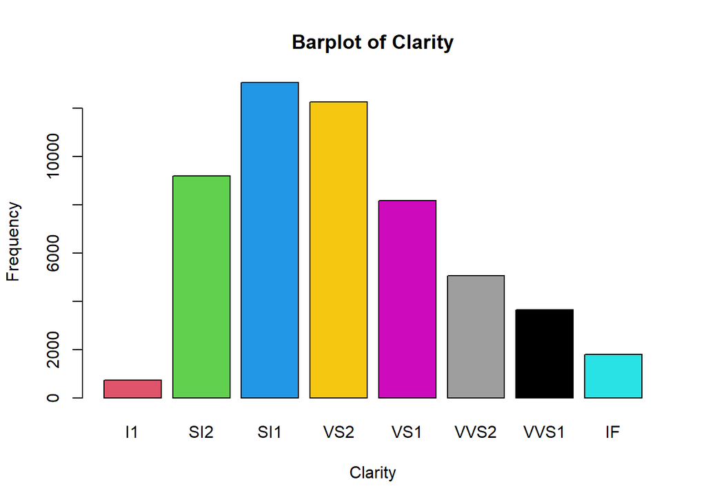

```r
barplot(table(diamonds$clarity), col = c(2, 3, 4, 7, 6, 8, 9, 5), main = 'Barplot of Clarity', xlab = "Clarity", ylab = "Frequency")
```

clarity plot

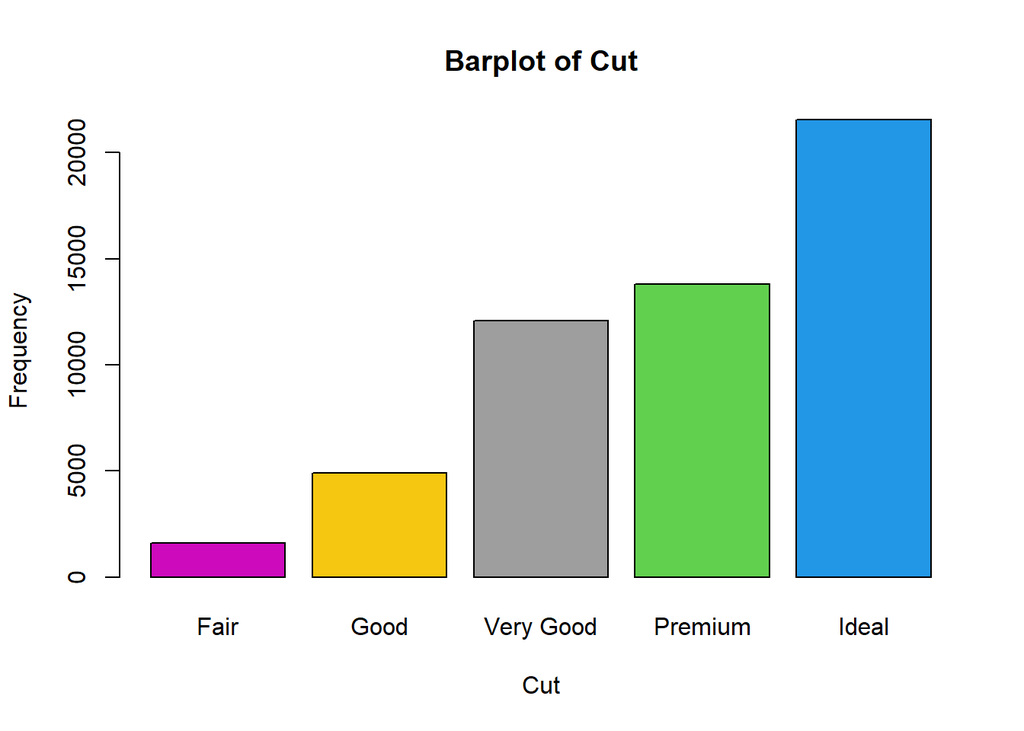

```r
barplot(table(diamonds$cut), col = c(6, 7, 8, 3, 4), main = 'Barplot of Cut', xlab = "Cut", ylab = "Frequency")
```

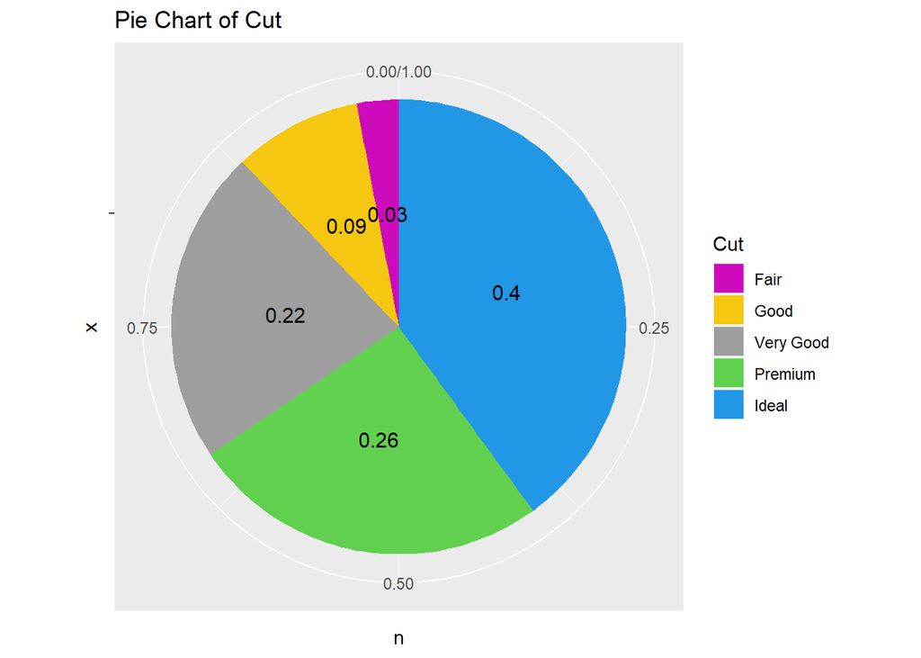

```r
cut_count = dplyr::count(diamonds, cut)
colnames(cut_count)[colnames(cut_count) == 'cut'] <- 'Cut'
cut_count$n = cut_count$n/sum(cut_count$n)

loadPkg("ggplot2")

ggplot(cut_count, aes(x = "", y = n, fill = Cut)) +
  geom_bar(stat="identity", width=1) +
  coord_polar("y", start=0) +
  geom_text(size = 4, aes(label = paste0(round(n, 2), "")), position = position_stack(vjust = 0.5))+
  scale_fill_manual(values = c(6, 7, 8, 3, 4))+
  labs(title='Pie Chart of Cut')
```

cut plot

### Continious Data Exploration

In this section we will look at all the continuous variables besides price.

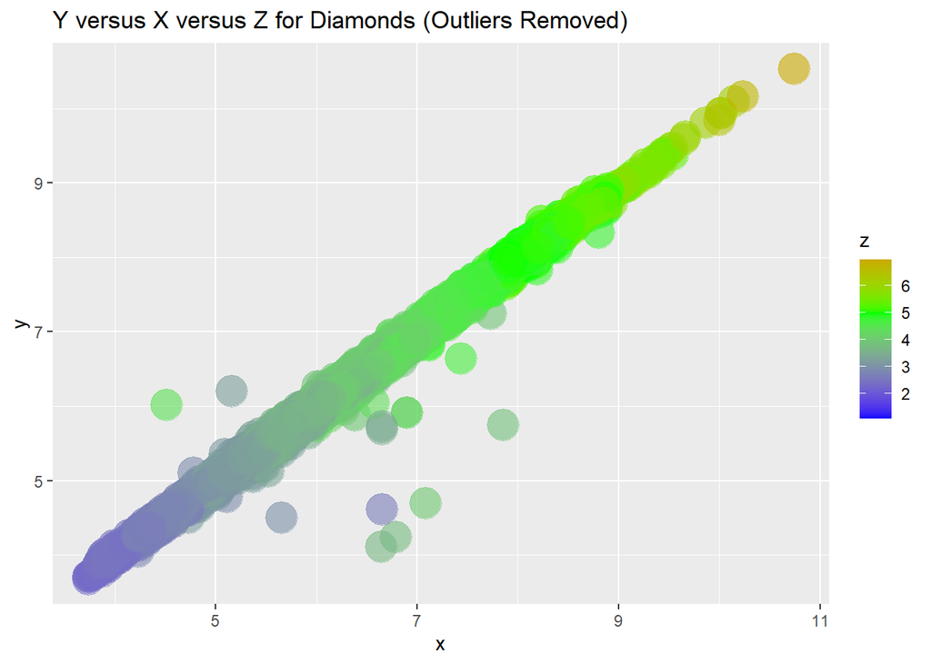

```r
diaNO = subset(diamonds, x > 0 & y > 0 & z > 0 & y <30 & z <30)
ggplot(diaNO, aes(x, y, color=z)) +
  geom_point(size = 8, alpha = 0.6) +
  ggtitle('Y versus X versus Z for Diamonds (Outliers Removed)') +
  scale_color_gradient2(midpoint = 5, low="blue", mid="green", high="red")
```

x vs y vs z

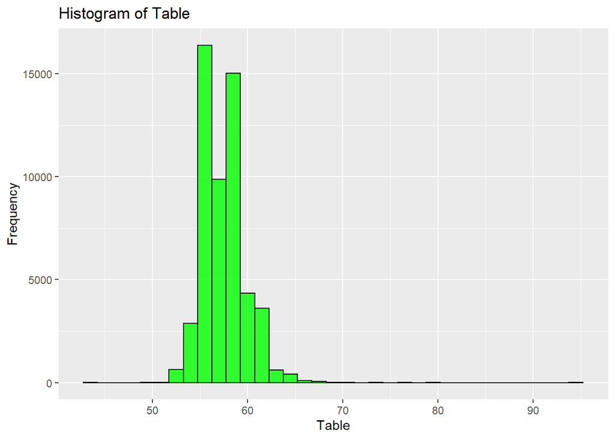

```r
ggplot(diamonds, aes(y=table)) +
  geom_histogram(col="black",
                 fill="green",
                  alpha = .8,
                 binwidth = 1.5) +
  labs(title='Histogram of Table') +
  coord_flip() +
  labs(y="Table", x="Frequency")
```

table plot

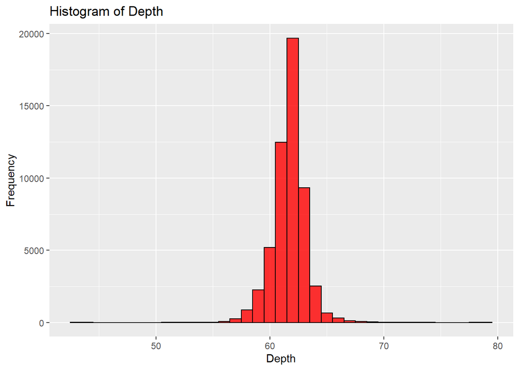

```r
ggplot(diamonds, aes(y=depth)) +
  geom_histogram(col="black",
                 fill="red",
                  alpha = .8,
                 binwidth = 1) +
  coord_flip() +
  labs(title='Histogram of Depth') +
  labs(y="Depth", x="Frequency")
```

depth plot

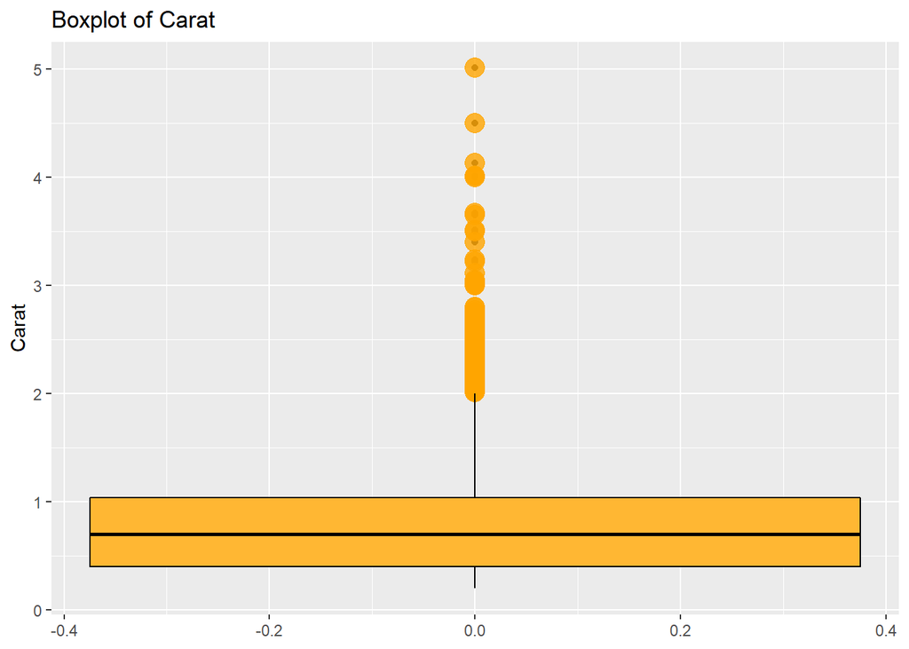

```r
ggplot(diamonds, aes(y=carat)) +
  geom_boxplot() +
  geom_boxplot(colour="black", fill="orange", outlier.colour="orange", outlier.size=5, alpha = 0.8) +
  labs(title = 'Boxplot of Carat')+
  labs(y="Carat")
```

carat plot

### Price Exploration

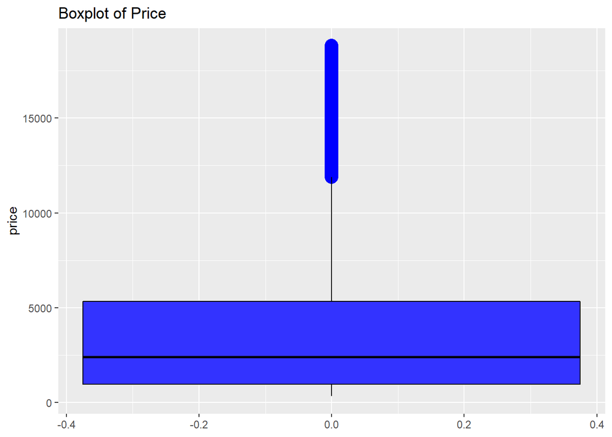

```r
ggplot(diamonds, aes(y=price)) +
  geom_boxplot() +
  geom_boxplot(colour="black", fill="blue", outlier.colour="blue", outlier.size=5, alpha = 0.8) +
  labs(title = 'Boxplot of Price')
```

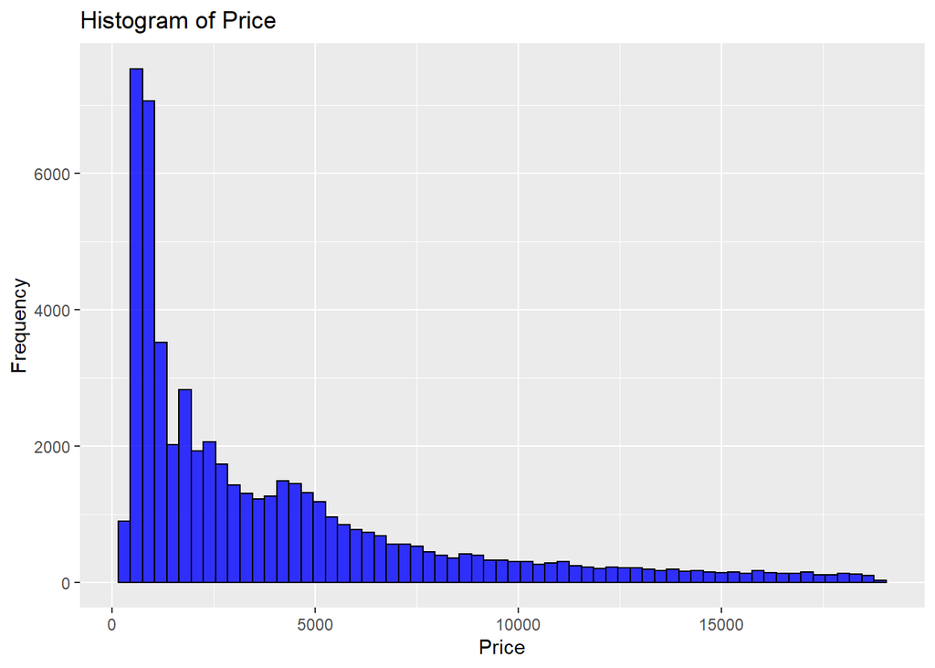

```r
ggplot(diamonds, aes(y=price)) +
  geom_histogram(col="black",
                 fill="blue",
                  alpha = .8,
                 binwidth = 300) +
  coord_flip() +
  labs(title='Histogram of Price') +
  labs(y="Price", x="Frequency")
```

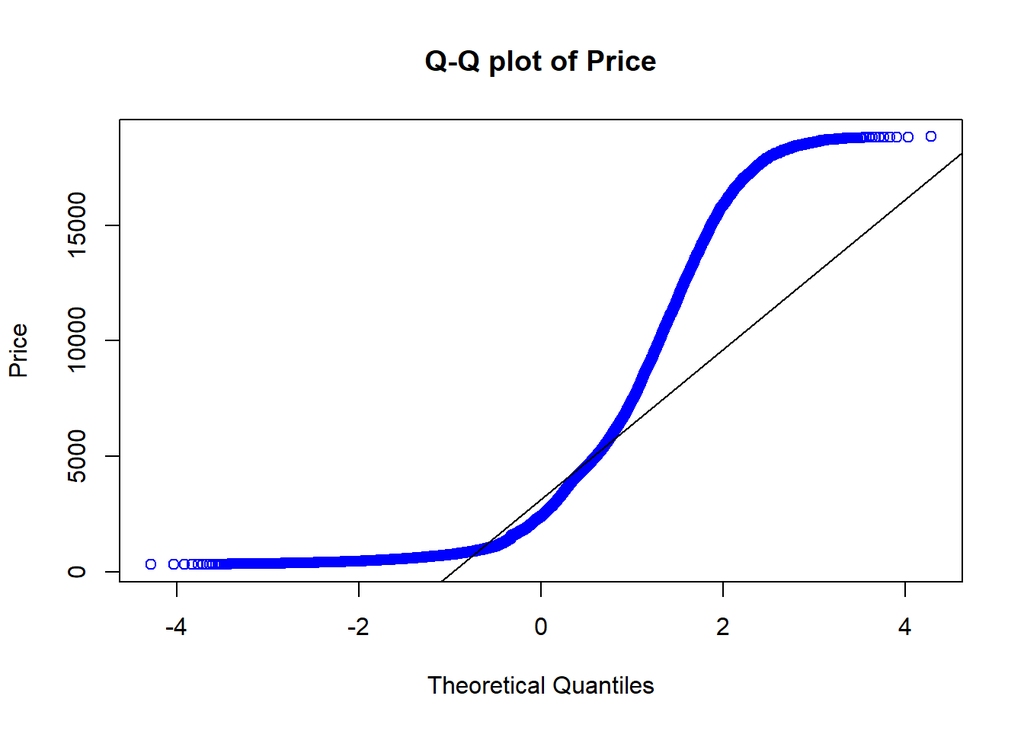

```r
qqnorm(diamonds$price, main="Q-Q plot of Price", col = 'blue', ylab = 'Price')
qqline(diamonds$price)
```

price plot

## Adam - Linear Regression to predict price

### single variables

one model for each individual

```r
modelcarat <- lm(price ~ carat,data=diamonds)
modeldepth <- lm(price ~ depth,data=diamonds)
modeltable <- lm(price ~ table,data=diamonds)
modelx <- lm(price ~ x,data=diamonds)
modely <- lm(price ~ y,data=diamonds)
modelz <- lm(price ~ z,data=diamonds)
```

```r
loadPkg("sjPlot")
```

[output not shown]

```r
loadPkg("sjmisc")
loadPkg("sjlabelled")
tab_model(modelcarat)
```

|  | price |  |  |
| --- | --- | --- | --- |
| Predictors | Estimates | CI | p |
| (Intercept) | -2256.36 | -2281.95 – -2230.77 | **<0.001** |
| carat | 7756.43 | 7728.86 – 7784.00 | **<0.001** |
| Observations | 53940 |  |  |
| R<sup>2</sup> / R<sup>2</sup> adjusted | 0.849 / 0.849 |  |  |

```r
tab_model(modeldepth)
```

|  | price |  |  |
| --- | --- | --- | --- |
| Predictors | Estimates | CI | p |
| (Intercept) | 5763.67 | 4312.17 – 7215.16 | **<0.001** |
| depth | -29.65 | -53.15 – -6.15 | **0.013** |
| Observations | 53940 |  |  |
| R<sup>2</sup> / R<sup>2</sup> adjusted | 0.000 / 0.000 |  |  |

```r
tab_model(modeltable)
```

|  | price |  |  |
| --- | --- | --- | --- |
| Predictors | Estimates | CI | p |
| (Intercept) | -9109.05 | -9968.41 – -8249.68 | **<0.001** |
| table | 226.98 | 212.04 – 241.93 | **<0.001** |
| Observations | 53940 |  |  |
| R<sup>2</sup> / R<sup>2</sup> adjusted | 0.016 / 0.016 |  |  |

```r
tab_model(modelx)
```

|  | price |  |  |
| --- | --- | --- | --- |
| Predictors | Estimates | CI | p |
| (Intercept) | -14094.06 | -14175.85 – -14012.26 | **<0.001** |
| x | 3145.41 | 3131.41 – 3159.42 | **<0.001** |
| Observations | 53940 |  |  |
| R<sup>2</sup> / R<sup>2</sup> adjusted | 0.782 / 0.782 |  |  |

```r
tab_model(modely)
```

|  | price |  |  |
| --- | --- | --- | --- |
| Predictors | Estimates | CI | p |
| (Intercept) | -13402.03 | -13488.39 – -13315.66 | **<0.001** |
| y | 3022.89 | 3008.12 – 3037.66 | **<0.001** |
| Observations | 53940 |  |  |
| R<sup>2</sup> / R<sup>2</sup> adjusted | 0.749 / 0.749 |  |  |

```r
tab_model(modelz)
```

|  | price |  |  |
| --- | --- | --- | --- |
| Predictors | Estimates | CI | p |
| (Intercept) | -13296.57 | -13384.05 – -13209.08 | **<0.001** |
| z | 4868.79 | 4844.55 – 4893.04 | **<0.001** |
| Observations | 53940 |  |  |
| R<sup>2</sup> / R<sup>2</sup> adjusted | 0.742 / 0.742 |  |  |

ANOVA of models

```r
anovaRes = anova(modelcarat,modelx,modely,modelz)
xkabledply(anovaRes, title = "ANOVA comparison between the models")
```

ANOVA comparison between the models

| Res.Df | RSS | Df | Sum of Sq | F | Pr(>F) |
| --- | --- | --- | --- | --- | --- |
| 53938 | 1.29e+11 | NA | NA | NA | NA |
| 53938 | 1.87e+11 | 0 | -5.76e+10 | NA | NA |
| 53938 | 2.16e+11 | 0 | -2.86e+10 | NA | NA |
| 53938 | 2.22e+11 | 0 | -6.18e+09 | NA | NA |

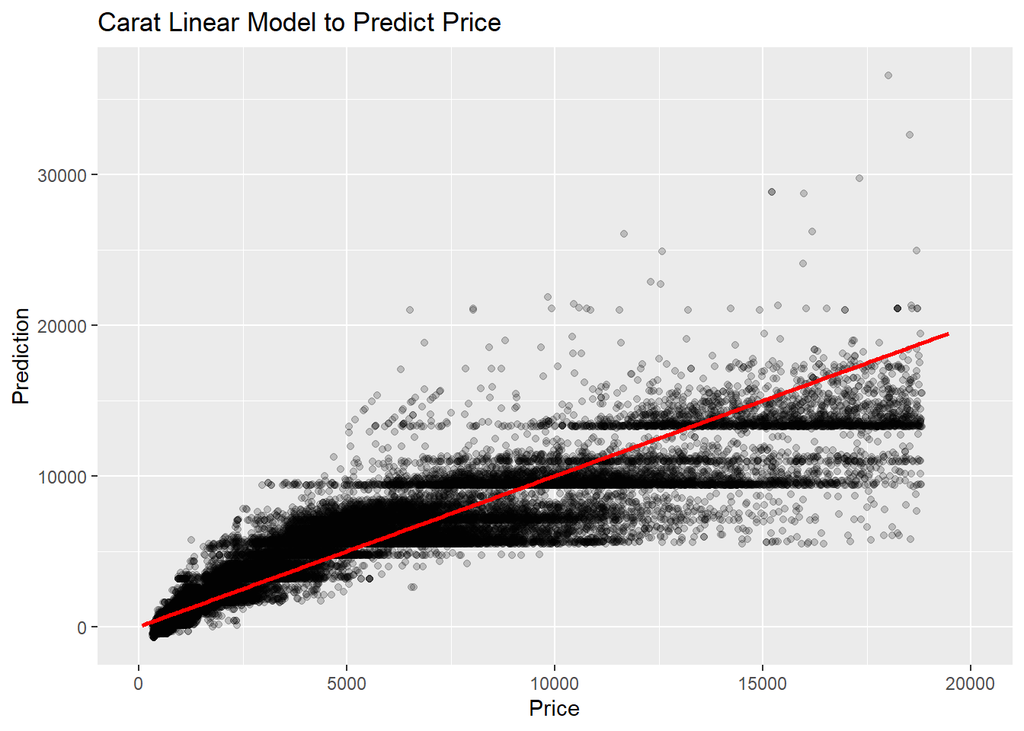

```r
loadPkg("modelr")
df.with.predfin.from.model <- add_predictions(diamonds,modelcarat)
head(df.with.predfin.from.model)
loadPkg("ggplot2")
ggplot(df.with.predfin.from.model,aes(price,pred))+geom_point(aes(price,pred), alpha =0.2)+geom_line(aes(pred), colour="red", size=1) + labs(title = "Carat Linear Model to Predict Price", x = "Price", y = "Prediction") + xlim(c(0, 20000))
```

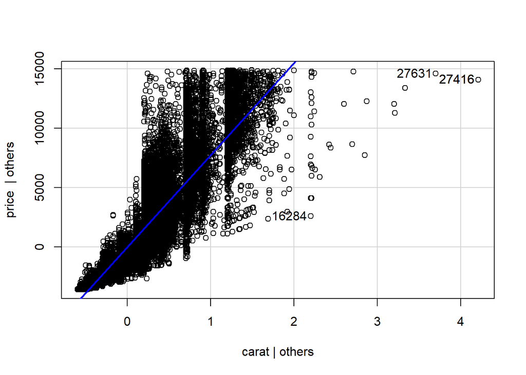

```r
loadPkg("car")
avPlots(modelcarat)
```

Carat is the best singular model

### multinumeric variables

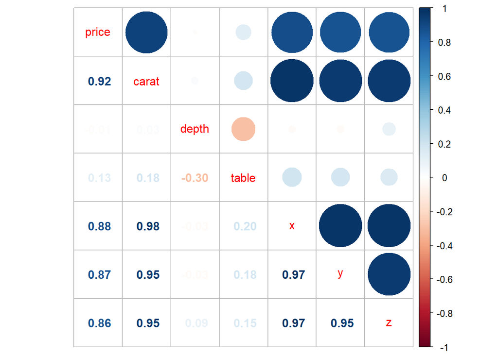

```r
diamondsnum =  subset(diamonds, select = c("price", "carat", "depth", "table", "x", "y", "z"))
diamondscor = cor(diamondsnum)
loadPkg("corrplot")
corrplot.mixed(diamondscor)
```

high correlation between many variables

```r
#loadPkg("lattice")
#pairs(diamondsnum[1:4])
```

removed the pairs plot for now cause I did not use in presentation and it takes too long to run

```r
modelcaratx <- lm(price ~ carat+x,data=diamonds)
tab_model(modelcaratx)
```

|  | price |  |  |
| --- | --- | --- | --- |
| Predictors | Estimates | CI | p |
| (Intercept) | 1737.95 | 1534.85 – 1941.05 | **<0.001** |
| carat | 10125.99 | 10003.38 – 10248.59 | **<0.001** |
| x | -1026.86 | -1078.67 – -975.05 | **<0.001** |
| Observations | 53940 |  |  |
| R<sup>2</sup> / R<sup>2</sup> adjusted | 0.853 / 0.853 |  |  |

```r
xkablevif(modelcaratx)
```

VIFs of the model

| carat | x |
| --- | --- |
| 20.3 | 20.3 |

```r
modelcarattable <- lm(price ~ carat+table,data=diamonds)
tab_model(modelcarattable)
```

|  | price |  |  |
| --- | --- | --- | --- |
| Predictors | Estimates | CI | p |
| (Intercept) | 1961.99 | 1625.24 – 2298.74 | **<0.001** |
| carat | 7820.04 | 7792.16 – 7847.92 | **<0.001** |
| table | -74.30 | -80.22 – -68.39 | **<0.001** |
| Observations | 53940 |  |  |
| R<sup>2</sup> / R<sup>2</sup> adjusted | 0.851 / 0.851 |  |  |

```r
xkablevif(modelcarattable)
```

VIFs of the model

| carat | table |
| --- | --- |
| 1.03 | 1.03 |

```r
modeldepthx <- lm(price ~ depth+x,data=diamonds)
tab_model(modeldepthx)
```

|  | price |  |  |
| --- | --- | --- | --- |
| Predictors | Estimates | CI | p |
| (Intercept) | -16116.57 | -16800.73 – -15432.42 | **<0.001** |
| depth | 32.66 | 21.69 – 43.62 | **<0.001** |
| x | 3146.47 | 3132.46 – 3160.47 | **<0.001** |
| Observations | 53940 |  |  |
| R<sup>2</sup> / R<sup>2</sup> adjusted | 0.782 / 0.782 |  |  |

```r
xkablevif(modeldepthx)
```

VIFs of the model

| depth | x |
| --- | --- |
| 1 | 1 |

There is no way to fix this from looking online

### multi numeric+continious variables

trying out different models

```r
modelcaratcut <- lm(price ~ carat+cut, data = diamonds)
tab_model(modelcaratcut)
```

|  | price |  |  |
| --- | --- | --- | --- |
| Predictors | Estimates | CI | p |
| (Intercept) | -2701.38 | -2731.62 – -2671.13 | **<0.001** |
| carat | 7871.08 | 7843.68 – 7898.48 | **<0.001** |
| cut [linear] | 1239.80 | 1188.64 – 1290.96 | **<0.001** |
| cut [quadratic] | -528.60 | -573.94 – -483.26 | **<0.001** |
| cut [cubic] | 367.91 | 328.29 – 407.53 | **<0.001** |
| cut [4th degree] | 74.59 | 42.76 – 106.42 | **<0.001** |
| Observations | 53940 |  |  |
| R<sup>2</sup> / R<sup>2</sup> adjusted | 0.856 / 0.856 |  |  |

```r
xkablevif(modelcaratcut)
```

VIFs of the model

| carat | cut.C | cut.L | cut.Q | cut^4 |
| --- | --- | --- | --- | --- |
| 1.04 | 2 | 2.67 | 1.75 | 1.24 |

```r
modelcaratclarity <- lm(price ~ carat+clarity, data = diamonds)
tab_model(modelcaratclarity)
```

|  | price |  |  |
| --- | --- | --- | --- |
| Predictors | Estimates | CI | p |
| (Intercept) | -2977.27 | -3002.97 – -2951.57 | **<0.001** |
| carat | 8440.06 | 8415.26 – 8464.85 | **<0.001** |
| clarity [linear] | 4216.78 | 4150.81 – 4282.74 | **<0.001** |
| clarity [quadratic] | -1931.41 | -1993.87 – -1868.94 | **<0.001** |
| clarity [cubic] | 1005.85 | 952.16 – 1059.54 | **<0.001** |
| clarity [4th degree] | -480.18 | -523.19 – -437.17 | **<0.001** |
| clarity [5th degree] | 283.94 | 248.71 – 319.18 | **<0.001** |
| clarity [6th degree] | 12.66 | -18.07 – 43.40 | 0.419 |
| clarity [7th degree] | 198.05 | 170.97 – 225.13 | **<0.001** |
| Observations | 53940 |  |  |
| R<sup>2</sup> / R<sup>2</sup> adjusted | 0.895 / 0.895 |  |  |

```r
xkablevif(modelcaratclarity)
```

VIFs of the model

| carat | clarity.C | clarity.L | clarity.Q | clarity^4 | clarity^5 | clarity^6 | clarity^7 |
| --- | --- | --- | --- | --- | --- | --- | --- |
| 1.16 | 2.36 | 1.87 | 2.24 | 1.92 | 1.48 | 1.28 | 1.12 |

This model is the best

```r
modelcaratcolor <- lm(price ~ carat+color, data = diamonds)
tab_model(modelcaratcolor)
```

|  | price |  |  |
| --- | --- | --- | --- |
| Predictors | Estimates | CI | p |
| (Intercept) | -2702.23 | -2729.25 – -2675.22 | **<0.001** |
| carat | 8066.62 | 8039.11 – 8094.14 | **<0.001** |
| color [linear] | 1572.20 | 1528.46 – 1615.94 | **<0.001** |
| color [quadratic] | -741.14 | -781.13 – -701.16 | **<0.001** |
| color [cubic] | 122.70 | 85.17 – 160.22 | **<0.001** |
| color [4th degree] | 78.77 | 44.30 – 113.23 | **<0.001** |
| color [5th degree] | 144.74 | 112.16 – 177.32 | **<0.001** |
| color [6th degree] | -180.75 | -210.30 – -151.19 | **<0.001** |
| Observations | 53940 |  |  |
| R<sup>2</sup> / R<sup>2</sup> adjusted | 0.864 / 0.864 |  |  |

```r
xkablevif(modelcaratcolor)
```

VIFs of the model

| carat | color.C | color.L | color.Q | color^4 | color^5 | color^6 |
| --- | --- | --- | --- | --- | --- | --- |
| 1.1 | 1.28 | 1.22 | 1.2 | 1.16 | 1.06 | 1.03 |

```r
modelcaratccc <- lm(price ~ carat+color+cut+clarity, data = diamonds)
tab_model(modelcaratccc)
```

|  | price |  |  |
| --- | --- | --- | --- |
| Predictors | Estimates | CI | p |
| (Intercept) | -3710.60 | -3738.01 – -3683.20 | **<0.001** |
| carat | 8886.13 | 8862.54 – 8909.72 | **<0.001** |
| color [linear] | 1910.29 | 1875.57 – 1945.00 | **<0.001** |
| color [quadratic] | -627.95 | -659.55 – -596.36 | **<0.001** |
| color [cubic] | 171.96 | 142.42 – 201.50 | **<0.001** |
| color [4th degree] | 21.68 | -5.45 – 48.80 | 0.117 |
| color [5th degree] | 85.94 | 60.31 – 111.57 | **<0.001** |
| color [6th degree] | -49.99 | -73.29 – -26.68 | **<0.001** |
| cut [linear] | 698.91 | 659.05 – 738.76 | **<0.001** |
| cut [quadratic] | -327.69 | -362.79 – -292.58 | **<0.001** |
| cut [cubic] | 180.57 | 150.07 – 211.06 | **<0.001** |
| cut [4th degree] | -1.21 | -25.63 – 23.21 | 0.923 |
| clarity [linear] | 4217.53 | 4157.11 – 4277.96 | **<0.001** |
| clarity [quadratic] | -1832.41 | -1888.91 – -1775.90 | **<0.001** |
| clarity [cubic] | 923.27 | 874.90 – 971.64 | **<0.001** |
| clarity [4th degree] | -361.99 | -400.68 – -323.31 | **<0.001** |
| clarity [5th degree] | 216.62 | 185.04 – 248.19 | **<0.001** |
| clarity [6th degree] | 2.11 | -25.41 – 29.62 | 0.881 |
| clarity [7th degree] | 110.34 | 86.07 – 134.61 | **<0.001** |
| Observations | 53940 |  |  |
| R<sup>2</sup> / R<sup>2</sup> adjusted | 0.916 / 0.916 |  |  |

```r
xkablevif(modelcaratccc)
```

VIFs of the model

| carat | clarity.C | clarity.L | clarity.Q | clarity^4 | clarity^5 | clarity^6 | clarity^7 | color.C | color.L | color.Q | color^4 | color^5 | color^6 | cut.C | cut.L | cut.Q | cut^4 |
| --- | --- | --- | --- | --- | --- | --- | --- | --- | --- | --- | --- | --- | --- | --- | --- | --- | --- |
| 1.31 | 1.31 | 1.23 | 1.21 | 1.17 | 1.06 | 1.04 | 2.08 | 2.73 | 1.77 | 1.24 | 2.48 | 1.91 | 2.27 | 1.94 | 1.48 | 1.28 | 1.12 |

Now this model is the best

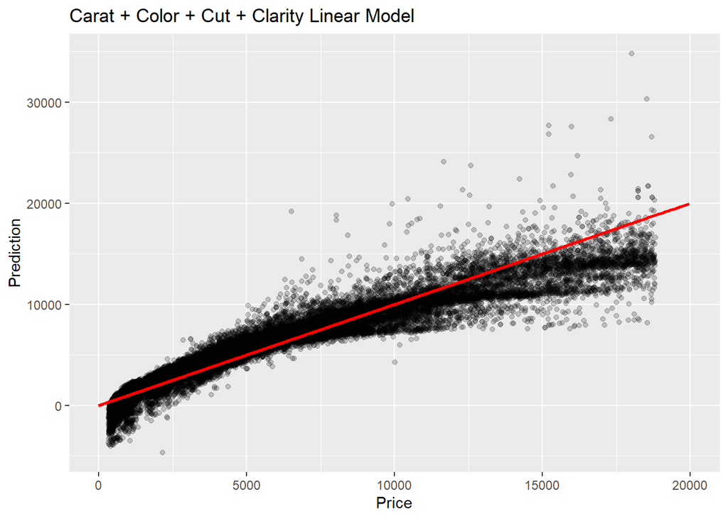

```r
df.with.predfin.from.model <- add_predictions(diamonds,modelcaratccc)
head(df.with.predfin.from.model)
loadPkg("ggplot2")
ggplot(df.with.predfin.from.model,aes(price,pred))+geom_point(aes(price,pred), alpha =0.2)+geom_line(aes(pred), colour="red", size=1) + labs(title = "Carat + Color + Cut + Clarity Linear Model", x = "Price", y = "Prediction") + xlim(c(0, 20000))
```

almost looks like a polynomial curve?

### interaction terms

```r
modelcaratccci <- lm(price ~ carat * clarity, data = diamonds)
tab_model(modelcaratccci)
```

|  | price |  |  |
| --- | --- | --- | --- |
| Predictors | Estimates | CI | p |
| (Intercept) | -2703.99 | -2736.96 – -2671.03 | **<0.001** |
| carat | 8746.14 | 8709.34 – 8782.95 | **<0.001** |
| clarity [linear] | -531.37 | -658.86 – -403.88 | **<0.001** |
| clarity [quadratic] | 470.47 | 345.59 – 595.36 | **<0.001** |
| clarity [cubic] | -926.21 | -1032.99 – -819.43 | **<0.001** |
| clarity [4th degree] | 693.74 | 609.23 – 778.25 | **<0.001** |
| clarity [5th degree] | -514.17 | -581.92 – -446.41 | **<0.001** |
| clarity [6th degree] | 166.53 | 108.70 – 224.36 | **<0.001** |
| clarity [7th degree] | -24.58 | -74.87 – 25.72 | 0.338 |
| carat * clarity [linear] | 5496.25 | 5361.14 – 5631.37 | **<0.001** |
| carat * clarity [quadratic] | -1037.76 | -1165.70 – -909.82 | **<0.001** |
| carat * clarity [cubic] | 1469.89 | 1354.08 – 1585.71 | **<0.001** |
| carat * clarity [4th degree] | -943.92 | -1045.34 – -842.51 | **<0.001** |
| carat * clarity [5th degree] | 674.63 | 586.02 – 763.23 | **<0.001** |
| carat * clarity [6th degree] | -30.09 | -106.66 – 46.48 | 0.441 |
| carat * clarity [7th degree] | 304.46 | 242.54 – 366.39 | **<0.001** |
| Observations | 53940 |  |  |
| R<sup>2</sup> / R<sup>2</sup> adjusted | 0.909 / 0.909 |  |  |

```r
xkablevif(modelcaratccci)
```

VIFs of the model

| carat | carat:clarity.C | carat:clarity.L | carat:clarity.Q | carat:clarity^4 | carat:clarity^5 | carat:clarity^6 | carat:clarity^7 | clarity.C | clarity.L | clarity.Q | clarity^4 | clarity^5 | clarity^6 | clarity^7 |
| --- | --- | --- | --- | --- | --- | --- | --- | --- | --- | --- | --- | --- | --- | --- |
| 2.94 | 10.1 | 8.59 | 10.2 | 8.52 | 6.28 | 5.22 | 4.44 | 10.2 | 8.21 | 10 | 11.6 | 9.9 | 7.65 | 5.19 |

pretty good model

```r
modelcaratccci2 <- lm(price ~ carat + (color+cut+clarity)^2, data = diamonds)
tab_model(modelcaratccci2)
```

|  | price |  |  |
| --- | --- | --- | --- |
| Predictors | Estimates | CI | p |
| (Intercept) | -3638.97 | -3676.26 – -3601.68 | **<0.001** |
| carat | 8881.10 | 8857.62 – 8904.58 | **<0.001** |
| color [linear] | 2336.13 | 2268.01 – 2404.24 | **<0.001** |
| color [quadratic] | -388.93 | -451.66 – -326.21 | **<0.001** |
| color [cubic] | 178.61 | 121.20 – 236.02 | **<0.001** |
| color [4th degree] | 52.29 | 0.17 – 104.40 | **0.049** |
| color [5th degree] | 157.27 | 110.62 – 203.91 | **<0.001** |
| color [6th degree] | -25.23 | -66.07 – 15.62 | 0.226 |
| cut [linear] | 746.14 | 659.74 – 832.54 | **<0.001** |
| cut [quadratic] | -345.13 | -421.05 – -269.21 | **<0.001** |
| cut [cubic] | 212.89 | 153.99 – 271.79 | **<0.001** |
| cut [4th degree] | -1.07 | -46.51 – 44.36 | 0.963 |
| clarity [linear] | 4479.14 | 4360.03 – 4598.25 | **<0.001** |
| clarity [quadratic] | -1635.44 | -1745.23 – -1525.66 | **<0.001** |
| clarity [cubic] | 1013.53 | 914.76 – 1112.29 | **<0.001** |
| clarity [4th degree] | -369.33 | -457.75 – -280.91 | **<0.001** |
| clarity [5th degree] | 173.53 | 98.12 – 248.95 | **<0.001** |
| clarity [6th degree] | -6.35 | -66.48 – 53.78 | 0.836 |
| clarity [7th degree] | 92.66 | 47.40 – 137.92 | **<0.001** |
| color [linear] * cut [linear] | -156.52 | -285.46 – -27.59 | **0.017** |
| color [quadratic] * cut [linear] | -6.35 | -126.94 – 114.23 | 0.918 |
| color [cubic] * cut [linear] | 191.17 | 76.29 – 306.04 | **0.001** |
| color [4th degree] * cut [linear] | 115.55 | 5.20 – 225.90 | **0.040** |
| color [5th degree] * cut [linear] | 4.62 | -96.38 – 105.62 | 0.929 |
| color [6th degree] * cut [linear] | -44.86 | -137.62 – 47.90 | 0.343 |
| color [linear] * cut [quadratic] | 17.55 | -96.35 – 131.44 | 0.763 |
| color [quadratic] * cut [quadratic] | -10.65 | -117.32 – 96.03 | 0.845 |
| color [cubic] * cut [quadratic] | -117.92 | -219.52 – -16.32 | **0.023** |
| color [4th degree] * cut [quadratic] | -12.06 | -109.33 – 85.21 | 0.808 |

[output cut: 86 more lines]

```r
xkablevif(modelcaratccci2)
```

VIFs of the model

| carat | clarity.C | clarity.L | clarity.Q | clarity^4 | clarity^5 | clarity^6 | clarity^7 | color.C | color.C:clarity.C | color.C:clarity.L | color.C:clarity.Q | color.C:clarity^4 | color.C:clarity^5 | color.C:clarity^6 | color.C:clarity^7 | color.C:cut.C | color.C:cut.L | color.C:cut.Q | color.C:cut^4 | color.L | color.L:clarity.C | color.L:clarity.L | color.L:clarity.Q | color.L:clarity^4 | color.L:clarity^5 | color.L:clarity^6 | color.L:clarity^7 | color.L:cut.C | color.L:cut.L | … |
| --- | --- | --- | --- | --- | --- | --- | --- | --- | --- | --- | --- | --- | --- | --- | --- | --- | --- | --- | --- | --- | --- | --- | --- | --- | --- | --- | --- | --- | --- | --- |
| 1.34 | 5.18 | 5 | 4.68 | 4.43 | 3.62 | 3.27 | 10 | 13.1 | 6.79 | 4.42 | 9.89 | 7.42 | 9.76 | 10.4 | 8.7 | 6.31 | 4.02 | 3.87 | 4.02 | 3.82 | 4.12 | 3.46 | 3.56 | 3.22 | 3.32 | 3.1 | 3.28 | 2.81 | 2.8 | … |

high VIF values

```r
modelcaratccci3 <- lm(price ~ (carat + clarity)^2, data = diamonds)
tab_model(modelcaratccci3)
```

|  | price |  |  |
| --- | --- | --- | --- |
| Predictors | Estimates | CI | p |
| (Intercept) | -2703.99 | -2736.96 – -2671.03 | **<0.001** |
| carat | 8746.14 | 8709.34 – 8782.95 | **<0.001** |
| clarity [linear] | -531.37 | -658.86 – -403.88 | **<0.001** |
| clarity [quadratic] | 470.47 | 345.59 – 595.36 | **<0.001** |
| clarity [cubic] | -926.21 | -1032.99 – -819.43 | **<0.001** |
| clarity [4th degree] | 693.74 | 609.23 – 778.25 | **<0.001** |
| clarity [5th degree] | -514.17 | -581.92 – -446.41 | **<0.001** |
| clarity [6th degree] | 166.53 | 108.70 – 224.36 | **<0.001** |
| clarity [7th degree] | -24.58 | -74.87 – 25.72 | 0.338 |
| carat * clarity [linear] | 5496.25 | 5361.14 – 5631.37 | **<0.001** |
| carat * clarity [quadratic] | -1037.76 | -1165.70 – -909.82 | **<0.001** |
| carat * clarity [cubic] | 1469.89 | 1354.08 – 1585.71 | **<0.001** |
| carat * clarity [4th degree] | -943.92 | -1045.34 – -842.51 | **<0.001** |
| carat * clarity [5th degree] | 674.63 | 586.02 – 763.23 | **<0.001** |
| carat * clarity [6th degree] | -30.09 | -106.66 – 46.48 | 0.441 |
| carat * clarity [7th degree] | 304.46 | 242.54 – 366.39 | **<0.001** |
| Observations | 53940 |  |  |
| R<sup>2</sup> / R<sup>2</sup> adjusted | 0.909 / 0.909 |  |  |

```r
xkablevif(modelcaratccci3)
```

VIFs of the model

| carat | carat:clarity.C | carat:clarity.L | carat:clarity.Q | carat:clarity^4 | carat:clarity^5 | carat:clarity^6 | carat:clarity^7 | clarity.C | clarity.L | clarity.Q | clarity^4 | clarity^5 | clarity^6 | clarity^7 |
| --- | --- | --- | --- | --- | --- | --- | --- | --- | --- | --- | --- | --- | --- | --- |
| 2.94 | 10.1 | 8.59 | 10.2 | 8.52 | 6.28 | 5.22 | 4.44 | 10.2 | 8.21 | 10 | 11.6 | 9.9 | 7.65 | 5.19 |

pretty great again, but high VIF

Nothing with interaction terms beats the carat + ccc model

### feature selection

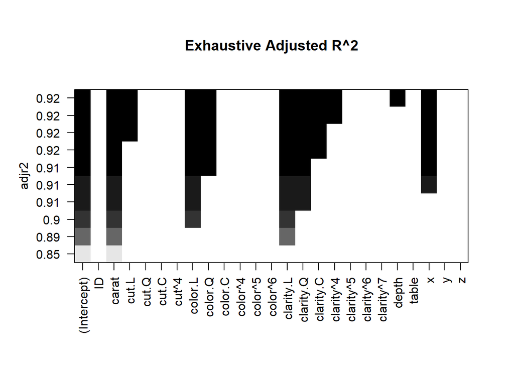

```r
loadPkg("leaps")
#This is essentially best fit
reg.best10 <- regsubsets(price~. , data = diamonds, nvmax = 10, nbest = 1, method = "exhaustive")  # leaps::regsubsets() - Model selection by exhaustive (default) search, forward or backward stepwise, or sequential replacement
#The plot will show the Adjust R^2 when using the variables across the bottom
plot(reg.best10, scale = "adjr2", main = "Exhaustive Adjusted R^2")
```

all types of models look the same, so just stick to adjusted R squared

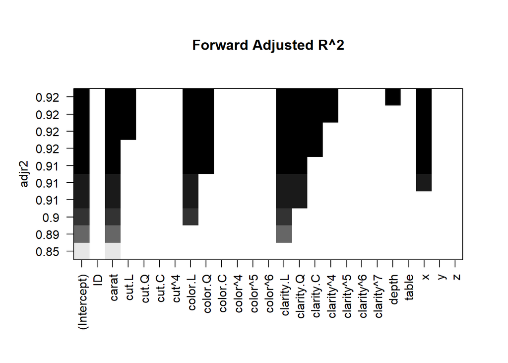

```r
reg.forward10 <- regsubsets(price~., data = diamonds, nvmax = 10, nbest = 1, method = "forward")
plot(reg.forward10, scale = "adjr2", main = "Forward Adjusted R^2")
```

```r
# summary(reg.forward10)
```

again all the same

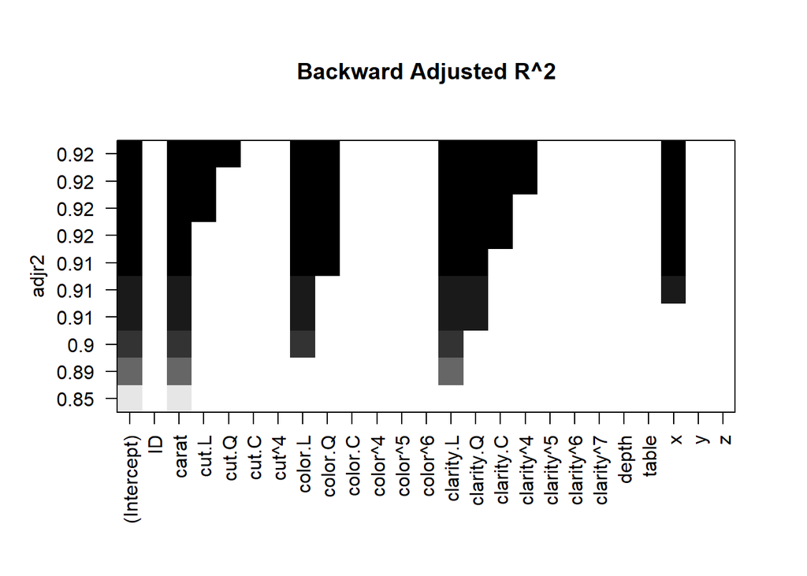

```r
reg.forward10 <- regsubsets(price~., data = diamonds, nvmax = 10, nbest = 1, method = "backward")
plot(reg.forward10, scale = "adjr2", main = "Backward Adjusted R^2")
```

```r
# summary(reg.forward10)
```

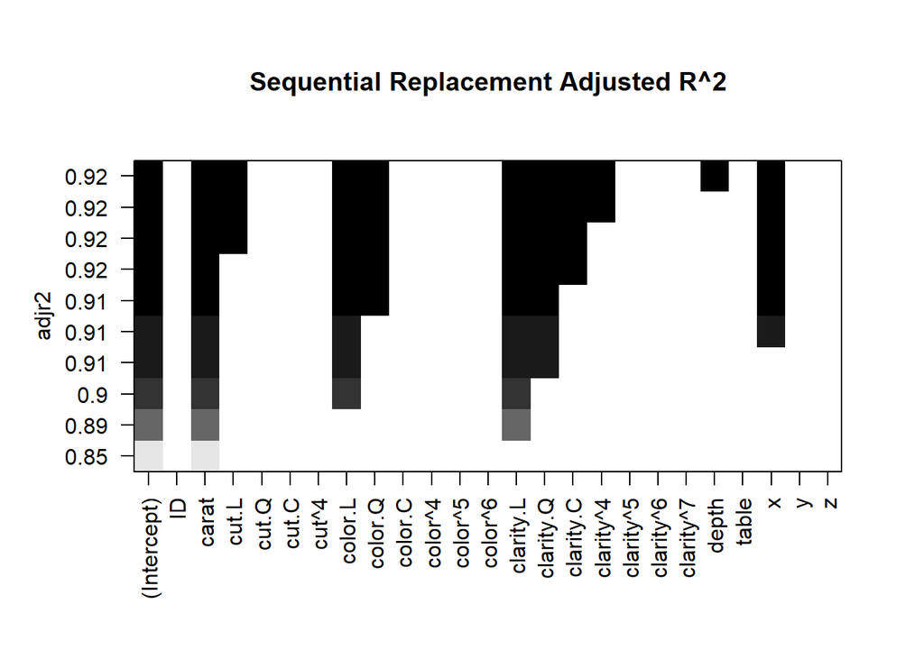

```r
reg.forward10 <- regsubsets(price~., data = diamonds, nvmax = 10, nbest = 1, method = "seqrep")
plot(reg.forward10, scale = "adjr2", main = "Sequential Replacement Adjusted R^2")
```

```r
# summary(reg.forward10)
```

same

All feature selections reflects our findings, and is all the same basically

## Suhas - PCR modeling to predict price

```r
diamondscont <- subset(diamonds, select = c ("carat", "depth", "table", "price", "x", "y", "z"))
```

#Standardize the data

```r
diamondscont <- as.data.frame(scale(diamondscont))
```

# Conduct PCR

```r
library(pls)
pcr_model <- pcr(price~., data = diamondscont,ncomp=6, validation = "CV")
summary(pcr_model)
```

```
## Data:    X dimension: 53940 6
##  Y dimension: 53940 1
## Fit method: svdpc
## Number of components considered: 6
##
## VALIDATION: RMSEP
## Cross-validated using 10 random segments.
##        (Intercept)  1 comps  2 comps  3 comps  4 comps  5 comps  6 comps
## CV               1    0.452   0.4497   0.4417   0.3886   0.3863   0.3759
## adjCV            1    0.452   0.4497   0.4417   0.3834   0.3868   0.3758
##
## TRAINING: % variance explained
##        1 comps  2 comps  3 comps  4 comps  5 comps  6 comps
## X        65.54    86.94    98.33    99.12    99.78   100.00
## price    79.57    79.77    80.49    85.01    85.21    85.92
```

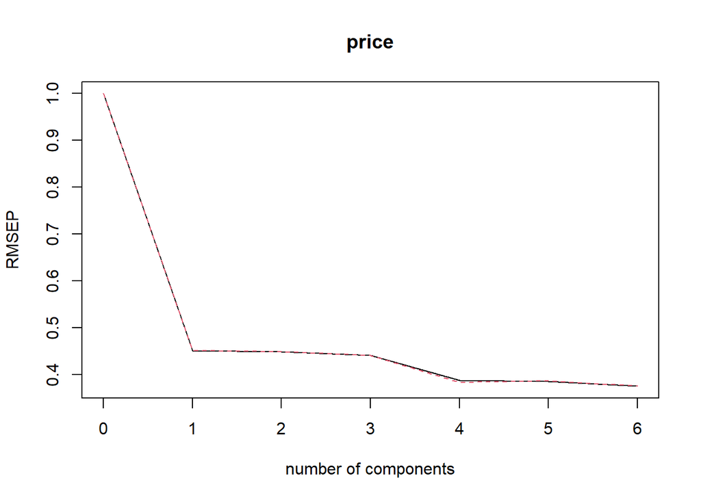

```r
validationplot(pcr_model)
```

```r
# We can see from the results of the PCR model that with just one component we can explain around 79 % of variance in price and as the components increase, the variance in price explained increases very marginally so it would make sense to build a model with just one variable.
```

# Linear regression model with 1 component

```r
linear_model_pcr_1a = lm(price~ x   , data= diamondscont)
summary(linear_model_pcr_1a)
```

```r
linear_model_pcr_1b = lm(price~ y   , data= diamondscont)
summary(linear_model_pcr_1b)
```

```r
linear_model_pcr_1c = lm(price~ z   , data= diamondscont)
summary(linear_model_pcr_1c)
```

```r
linear_model_pcr_1d = lm(price~ depth   , data= diamondscont)
summary(linear_model_pcr_1d)
```

```r
linear_model_pcr_1e = lm(price~ table   , data= diamondscont)
summary(linear_model_pcr_1e)
```

```r
linear_model_pcr_1f = lm(price~ carat   , data= diamondscont)
summary(linear_model_pcr_1f)
```

# Linear regression model with 2 components

```r
linear_model_pcr_2 = lm(price~ carat + y  , data= diamondscont)
summary(linear_model_pcr_2)

#calculate the vif value
xkablevif(linear_model_pcr_2)
```

# Linear regression model with 3 components

```r
linear_model_pcr_3 = lm(price~ carat + y + z , data= diamondscont)
summary(linear_model_pcr_3)
xkablevif(linear_model_pcr_3)
```

## Solomon - Random Forest Classification to predict cut

In this section we will be using the Random Forest model to build a classification model to be able to effectively classify diamonds into ‘Fair’, ‘Good’, ‘Very Good’, ‘Premium’, ‘Ideal’ diamond cuts, using the base features.

Prior to Random Forest Classification, Multi-nomial Logistic regression had been used but a very low accuracy score was found.

We start by removing missing values and outliers to make a good classification.

```r
mydiamonds=diamonds
mydiamonds[ mydiamonds == "?"] <- NA
colSums(is.na(mydiamonds))
# str(mydiamonds)
# boxplot(mydiamonds$price)
# any(is.na.data.frame(mydiamonds_clean))
mydiamonds_clean= subset(mydiamonds,!mydiamonds$price %in% boxplot.stats(mydiamonds$price)$out)
```

Upon removing outliers, 3538 outliers were detected and removed.

Next, we split our data set into training and testing set with 80% and 20% respectively.

```r
library(randomForest)
require(caTools)
library(MASS)
library(caret)
set.seed(1)
dataset= mydiamonds_clean[,2:11]
test= createDataPartition(dataset$cut,p=.2, list= FALSE)
data_train= dataset[-test,]
data_test= dataset[test,]
```

### Multinomial Logistic Regression

Before we dive into Random Forest Regression, lets perform a multinomial Logistic Regression and take a look at the accuracy score.

```r
require(nnet)
# Training the multinomial model
multinom_model <- multinom(cut ~ ., data = data_test)

# Checking the model
summary(multinom_model)

# Predicting the values for train dataset
classPredicted <- predict(multinom_model, newdata = data_test, "class")

# Confusion matrix
library(caret)
cmlogit=confusionMatrix(data_test$cut,classPredicted)
```

Logistic Regression has an accuracy score of 65.01%.

### Random Forest Regression

With Logsitic regression performing poorly, we will test Random Forest Regression.

First, we tune the Random Forest Model to get the best `mtry` (number of variables sampled at each split).

```
## mtry = 3  OOB error = 21.46%
## Searching left ...
## mtry = 6     OOB error = 21.34%
## 0.00555 0.05
## Searching right ...
## mtry = 1     OOB error = 25.41%
## -0.184 0.05
```

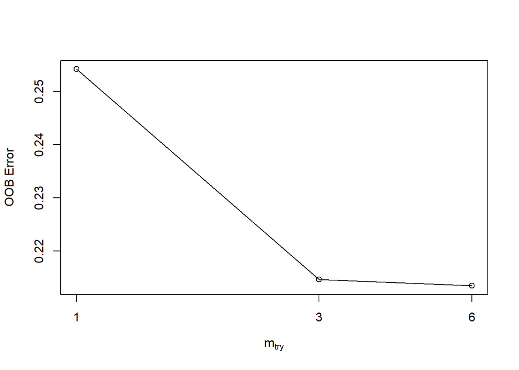

```r
# Tuning Random Forest to get the best mtry (number of variables random sampled as candidates at each split)
tune= tuneRF(data_train[,-2],data_train[,2], stepFactor = 0.5, plot=TRUE,
             ntreeTry=75,trace=TRUE, improve=0.05)
```

Note: `mtry` is the number of predictors sampled for splitting at each node.

The chart above helps us choose the best `mtry` to get a minimal Out of Bag Error. Obviously, 6 is the best `mtry` with less than 22% OOB error.

```r
rf<- randomForest(cut~ .,data=data_train,mtry=6, ntree=75) #fitting RandomForest Classification
pred = predict(rf, newdata=data_test[,-2]) # Prediction on test set
cm=confusionMatrix(data_test$cut,pred) #confusion matrix
print(rf)
```

```
##
## Call:
##  randomForest(formula = cut ~ ., data = data_train, mtry = 6,      ntree = 75)
##                Type of random forest: classification
##                      Number of trees: 75
## No. of variables tried at each split: 6
##
##         OOB estimate of  error rate: 21.4%
## Confusion matrix:
##           Fair Good Very Good Premium Ideal class.error
## Fair      1055   93        21      29     9       0.126
## Good       104 2637       796     125    50       0.290
## Very Good   10  575      5199    1347  1929       0.426
## Premium      0   43       954    7936  1093       0.208
## Ideal        5   31       816     584 14879       0.088
```

The random forest classifier has been modeled with mtry as 6 and ntree as 75..

```r
xkabledply(cm$table,title="Confusion Matrix")
```

Confusion Matrix

|  | Fair | Good | Very Good | Premium | Ideal |
| --- | --- | --- | --- | --- | --- |
| Fair | 272 | 18 | 2 | 8 | 2 |
| Good | 34 | 648 | 204 | 24 | 19 |
| Very Good | 3 | 138 | 1330 | 322 | 472 |
| Premium | 0 | 8 | 225 | 1978 | 296 |
| Ideal | 2 | 9 | 194 | 136 | 3738 |

```r
cm$overall
```

```
##       Accuracy          Kappa  AccuracyLower  AccuracyUpper   AccuracyNull
##       7.90e-01       7.02e-01       7.82e-01       7.98e-01       4.49e-01
## AccuracyPValue  McnemarPValue
##       0.00e+00       8.87e-44
```

The confusion matrix is seen above. Also, we get an accuracy score of 79.012% for the test dataset.

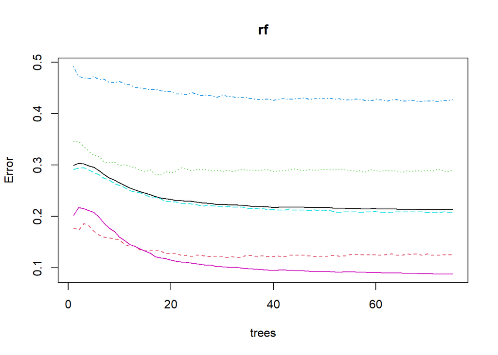

```r
plot(rf)
```

The graph above shows that as the trees increases the Out of Bag Error reduces. While a larger size of trees greater than 75 does not reduce the out of bag error significantly.

```r
round(importance(rf), 2)
```

```
##         MeanDecreaseGini
## carat               1085
## color               1082
## clarity              986
## depth               6933
## table               7925
## price               3057
## x                   3152
## y                   3039
## z                   1541
```

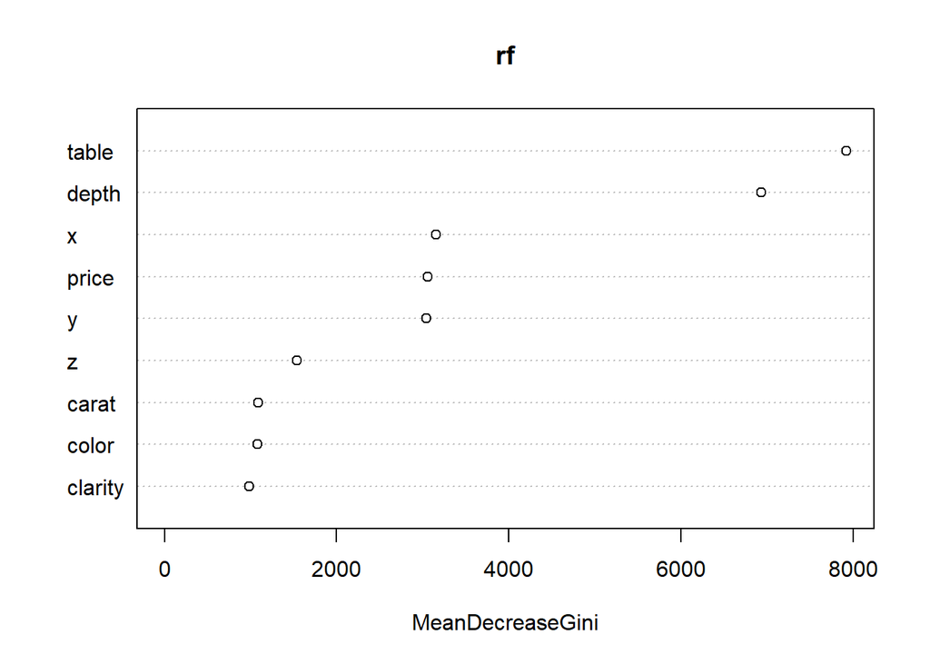

```r
# Mean Decrease in Gini is the average (mean) of a variable's total decrease in node impurity
varImpPlot(rf)
```

The mean decrease in Gini coefficient is a measure of how each variable contributes to the homogeneity of the nodes and leaves in the resulting random forest. The higher the value of mean decrease Gini score, the higher the importance of the variable in the model.

In the above chart, `table` and `depth` have the highest importance in the Random Forest model.

```r
set.seed(1)
dataset2= mydiamonds_clean[,c(2,3,4,6,7,8,9,10,11)]
test2= createDataPartition(dataset2$cut,p=.2, list= FALSE)
data_train2= dataset2[-test2,]
data_test2= dataset2[test2,]

rf2<- randomForest(cut~ .,data=data_train2,mtry=6, ntree=75) #fitting RandomForest Classification
pred2 = predict(rf2, newdata=data_test2[,-2]) # Prediction on test set
cm2=confusionMatrix(data_test2$cut,pred2) #confusion matrix
print(rf2)
```

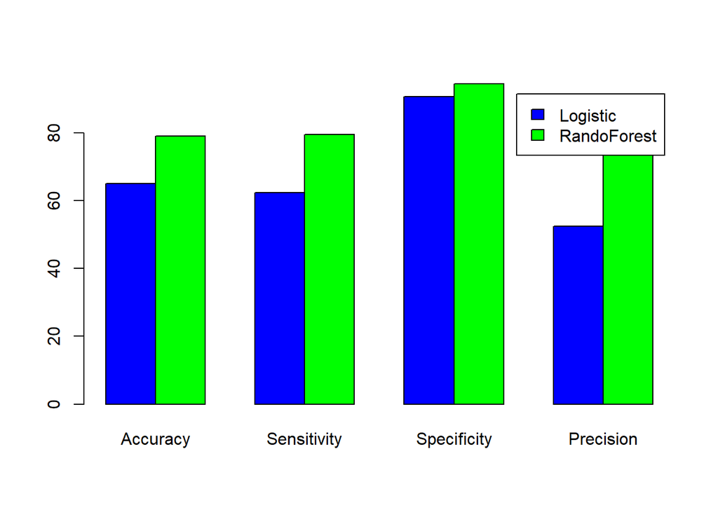

```r
check= data.frame()
# c('accuracy','precision','sensitivity','specificity')
check=rbind(check,c(round((sum(diag(cmlogit$table))/sum(cmlogit$table))*100,2)))
check=rbind(check,c(round((sum(diag(cm$table))/sum(cm$table))*100,2)))
rownames(check)=c('logistic','random forest')
colnames(check)=c("Accuracy Score")
check$AverageSensitiviy=c((sum(cmlogit$byClass[1:5])/5)*100,(sum(cm$byClass[1:5])/5)*100)
check$AverageSpecificity=c((sum(cmlogit$byClass[6:10])/5)*100,(sum(cm$byClass[6:10])/5)*100)
check$AveragePrecision=c((sum(cmlogit$byClass[21:25])/5)*100,(sum(cm$byClass[21:25])/5)*100)

barplot(height=as.matrix(check),beside=TRUE,names.arg = c("Accuracy","Sensitivity","Specificity","Precision"),legend.text = c("Logistic","RandoForest"),col=c("blue","green"))
```

The barplot above gives us a pictorial view of how Random Forest surpass Logistic regression for classifying diamond cut type.

## Huang - KNN modeling to predict cut

# pick numeric columns only

```r
knndata = diamonds[,c(2,3,6,7,8,9,10,11)]
knndata = as.data.frame(scale(knndata[,c(1,3,4,5,6,7,8)], center = TRUE, scale = TRUE))
```

# split data set

```r
set.seed(1000)
knn_sample <- sample(2, nrow(knndata), replace=TRUE, prob=c(0.75, 0.25))
knn_training <- knndata[knn_sample==1, ]
knn_test <- knndata[knn_sample==2, ]
trainLabels <- diamonds[knn_sample==1, 3]
testLabels <- diamonds[knn_sample==2, 3]
```

# build KNN model with K = 7

```r
loadPkg("FNN")
loadPkg("gmodels")
loadPkg("caret")
knn_pred <- knn(train = knn_training, test = knn_test, cl=trainLabels, k=7)
KNNCross <- CrossTable(testLabels, knn_pred, prop.chisq = FALSE)
```

# check different k values

```r
ResultDf = data.frame( k=numeric(0), Total.Accuracy= numeric(0), row.names = NULL )
for (kval in 3:15) {
  knn_pred <- knn(train = knn_training, test = knn_test, cl=trainLabels, k=kval)
  KNNCross <- CrossTable(testLabels, knn_pred, prop.chisq = FALSE)
  print( paste("k = ", kval) )
  KNNCross
  # get confusion matrix
  cm = confusionMatrix(knn_pred, reference = testLabels )
  # get accuracy score
  cmaccu = cm$overall['Accuracy']
  print( paste("Total Accuracy = ", cmaccu ) )
  # store into dataframe
  cmt = data.frame(k=kval, Total.Accuracy = cmaccu, row.names = NULL )
  ResultDf = rbind(ResultDf, cmt)
  print( xkabledply(   as.matrix(cm), title = paste("ConfusionMatrix for k = ",kval ) ) )
  print( xkabledply(data.frame(cm$byClass), title=paste("k = ",kval)) )
}
```

# show different accuracy values

```r
xkabledply(ResultDf, "Total Accuracy Summary")
```

# draw “accuracy vs k” plot

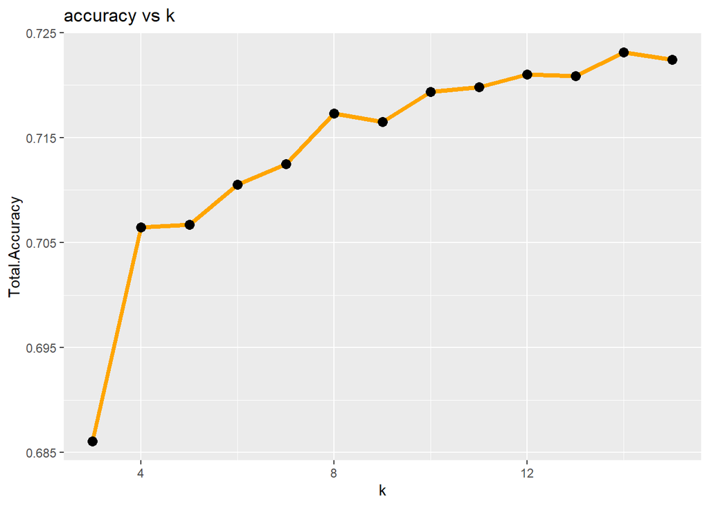

```r
loadPkg("ggplot2")
ggplot(ResultDf,
       aes(x = k, y = Total.Accuracy)) +
  geom_line(color = "orange", size = 1.5) +
  geom_point(size = 3) +
  labs(title = "accuracy vs k")
```